# Projekt: 732G33: del 1

*Författare:* Jakob Eklund & Pelle Nyberg

*Liu-id:* jakek854 & pelny705

*Grupp:* 06

# Introduktion

För kommunaldata har vi hämtat data för variablerna medelålder, medelinkomst, andel utlandsfödda, andel moppar och även befolkning. För tiddserie har vi hämtat data för konsumentprisindex (KPI) på riksnivå i Sverige. Tidsserien är på månadsnivå och innefattar perioden january 2012 till december 2021. Den innefattar en period om tio år och totalt 120 månader. Dessa månader har konverterats till ett datumintervall i paketet lubridate. Datan för KPI har konverterats så att den börjar med basen 100 där valt intervall börjar. All använd data har hämtats från SCB.

# Kommundata

Table 1

| Region | Medelålder | Inkomst | Utlandsfödda | Mopeder | Befolkning |
| --- | --- | --- | --- | --- | --- |
| Stenungsund | 41.7 | 583.2 | 11.634 | 0.642 | 27,556 |
| Tjörn | 46.1 | 640.2 | 9.269 | 6.744 | 16,312 |
| Orust | 47.9 | 529.3 | 8.980 | 3.135 | 15,345 |
| Sotenäs | 50.4 | 574.2 | 10.290 | 8.427 | 9,125 |
| Munkedal | 44.2 | 440.8 | 12.221 | 12.221 | 10,588 |

Table 2

| X. | Medelvärde | Median | Standardavikelse | Minumum | Maximum |
| --- | --- | --- | --- | --- | --- |
| Medelålder | 43.667 | 43.800 | 2.715 | 37.000 | 51.400 |
| Medelinkomst | 498.314 | 474.000 | 118.791 | 368.800 | 1,884.400 |
| Utlandsfödda | 15.825 | 14.510 | 6.409 | 6.977 | 43.363 |
| Moppar | 2.705 | 1.164 | 5.984 | 0.013 | 68.891 |
| Befolkning | 67,217.531 | 17,834.000 | 204,202.655 | 2,395.000 | 2,415,139.000 |

Ovan visar en tabell våra 4 variabler samt befolknings-variabeln. Tabllen visar dessa varibler samt vad medelvärdet,medianen, standardavikelsen, minsta och största obeservationen av samtliga variabler. I denna tabell till skillnad från den ovanför så är representerar variablerna Sveriges samtliga regioner, inte enbart våra utvalda kommuner

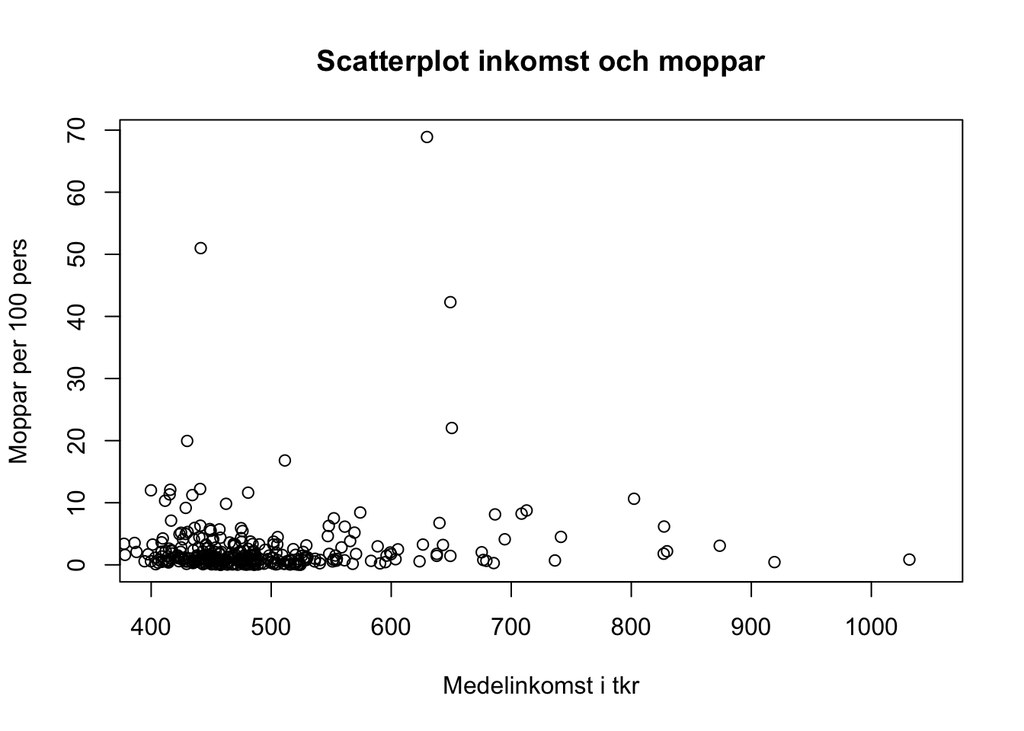

En scatter plot mellan variablerna medelinkomst och antal moppar per 100 personer. Det tycks inte föreligga någon signifikant korrelation mellan variablerna. Kommunen Danderyd utslöts ur plotten då dess medelinkomst låg nästan det dubbla av kommunen med näst högst inkomst.

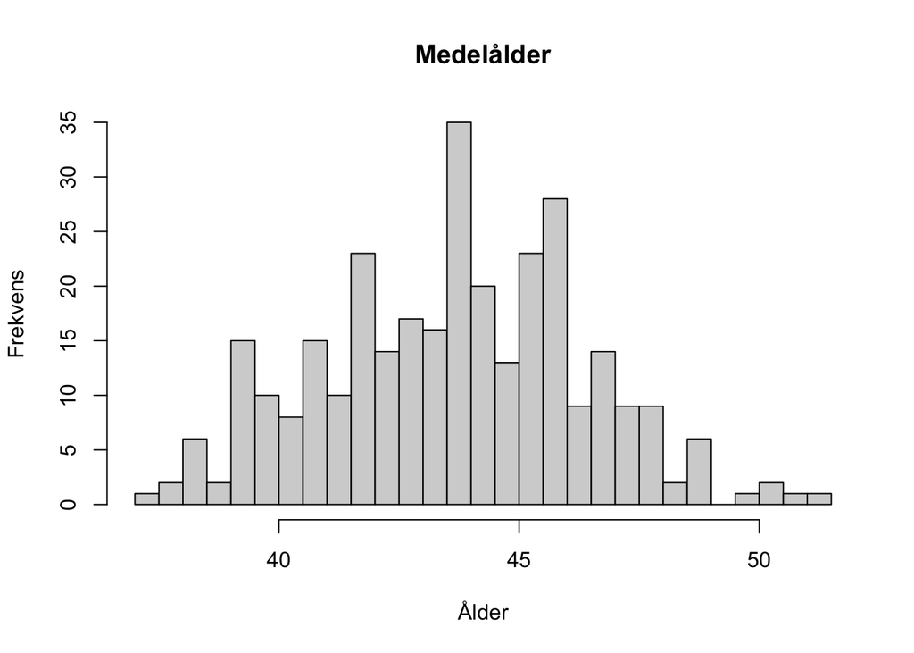

Histogram för medelålder

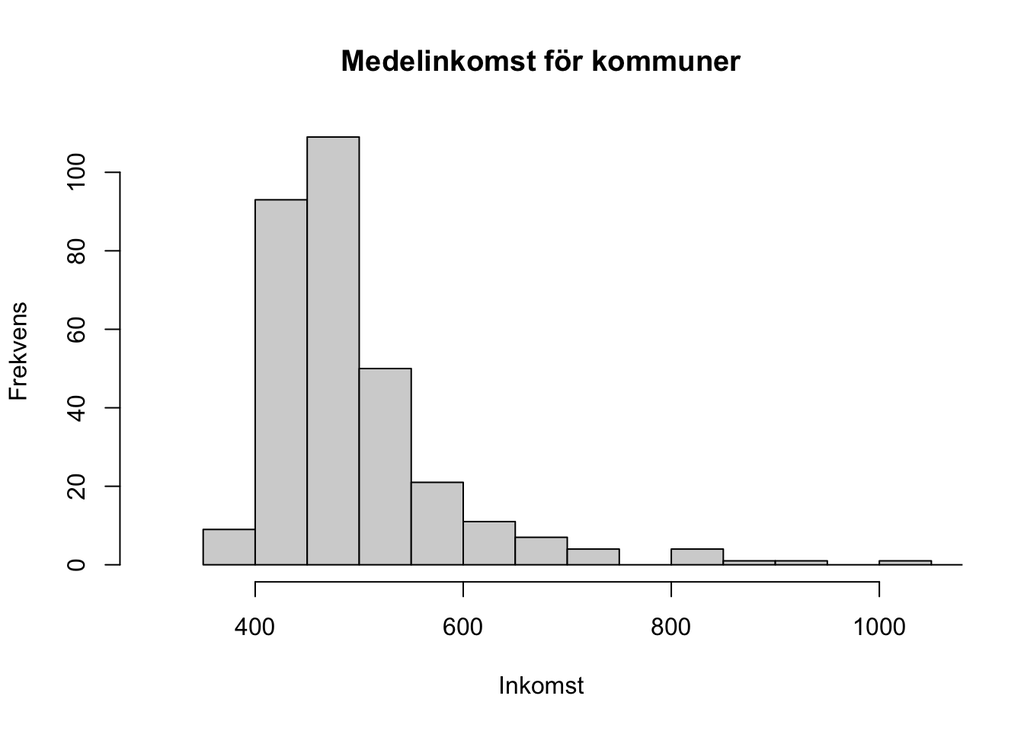

Data på medelinkomst för alla kommuner. Även här valt att exkludera Danderyd som annars ger ett fult histogram.

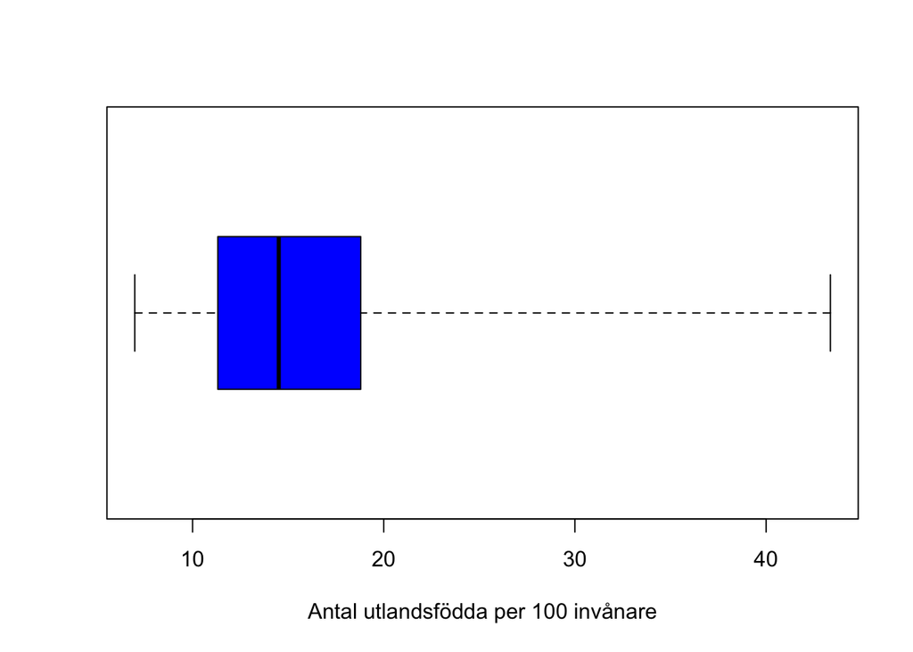

Ovan visar en boxplot över antalet utlandsfödda per 100 invånare över samtliga regioner i Sverige

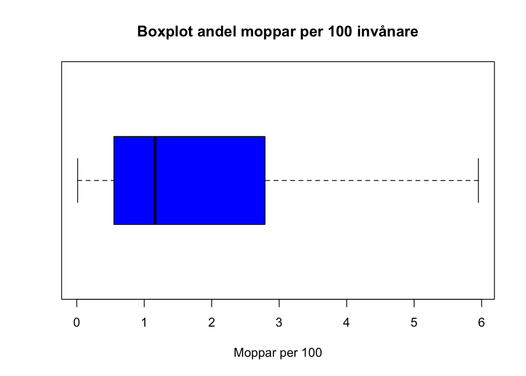

Ovan illustreras en boxplot på andel moppar i kommunerna per 100 invånare. Vi finner här en median strax över 1 moped per 100 invånare. I boxplotten har vi tagit beslutet att ignorera outliers då detta annars starkt förvränger figuren.

# Tidsseriedata

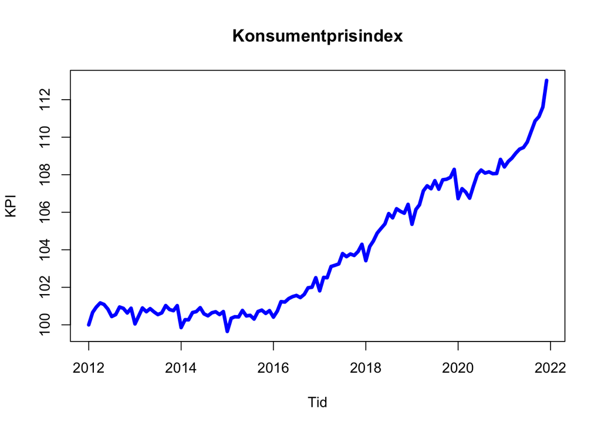

En tidsserie över perioden 1 january 2012 till 31 december 2021. Där data hämtas från SCB och perioden har justerats så att basåret är 2012.